# Multivariate Normal and R

Bealy MECH

10/18/2021

# Exercice 1 : IQ (Intelligence Quotient)

La probabilité pour que l’IQ est supérieur à 120 est donnée par:
$$P(I Q>120)=\int_{120}^{+\infty} f(x) d x$$
La probabilité pour que l’IQ est inférieur à 100 est donnée par:
$$P(I Q<100)=\int_{-\infty}^{100} f(x) d x$$

Ce qui peut etre calculé en $\mathrm{R}$ parla fonction $QI.Sup.120$ et $QI.Inf.100$ (pour cela il faut installer la $library(ggplot2)$)

The probability of having IQ:

- more than 120

```r
Psup120 <- 1-pnorm(120,100,15) # mean=100, sd=15
Psup120
```

```
## [1] 0.09121122
```

- less than 100

```r
Pinf100 <- pnorm(100,100,15)
Pinf100
```

```
## [1] 0.5
```

### Let’s see the graphe of the probability of having IQ more than 120

```r
# 1st solution
QI.Sup.120 <- function(x){
  ifelse(x>120, dnorm(x,mean=100,sd=15), NA)
}
# test
QI.Sup.120(140)
```

```
## [1] 0.0007597324
```

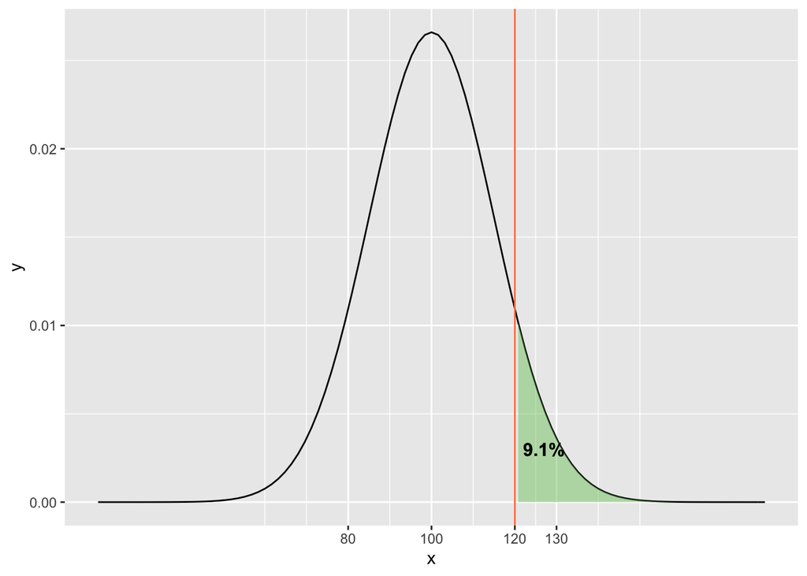

```r
library(ggplot2)
x <- c(20,180)
ggplot(data.frame(x), aes(x)) +
  stat_function(fun = dnorm, args = list(mean=100, sd=15)) +
  stat_function(fun = QI.Sup.120, geom = "area", fill="#84CA72", alpha=0.5, mapping = NULL) +
  geom_text(x=127, y=0.003, size=4, fontface="bold",
            label = paste0(round(pnorm(120, mean=100, sd=15, lower.tail = FALSE),3) * 100, "%")) +
  scale_x_continuous(breaks = c(80,100,120,130)) +
  geom_vline(xintercept = 120, colour = "coral")
```

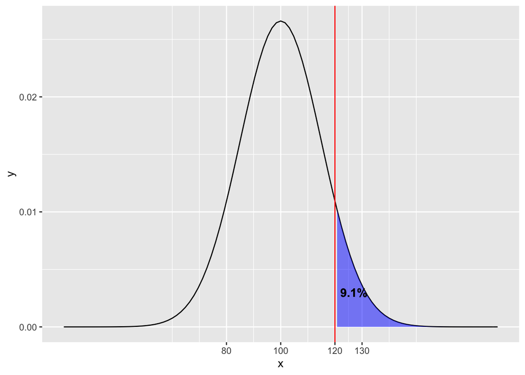

```r
# 2nd solution
IQ_sup_120 <- function(x){
  ifelse(x >120,dnorm(x, mean=100, sd=15),NA)
}
library(ggplot2)
ggplot(data.frame(x=c(20,180)),aes(x)) +
  stat_function(fun=dnorm,args=list(mean=100,sd=15)) +
  stat_function(fun=IQ_sup_120,geom="area", fill="blue", alpha=0.5) +
  geom_text(x=127, y=0.003, size=4, fontface="bold",
            label = paste0(round(pnorm(120, mean=100, sd=15, lower.tail = FALSE),3) * 100, "%")) +
  scale_x_continuous(breaks = c(80,100,120,130)) +
  geom_vline(xintercept = 120, colour = "red")
```

### Let’s see the graphe of the probability of having IQ less than 100

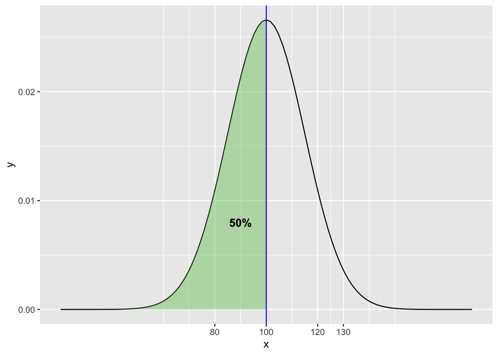

```r
# 1st solution
QI.Inf.100 <- function(x){
  ifelse(x<=100, dnorm(x,mean=100,sd=15), NA)
}

library(ggplot2)
x <- c(20,180)
ggplot(data.frame(x), aes(x)) +
  stat_function(fun = dnorm, args = list(mean=100, sd=15)) +
  stat_function(fun = QI.Inf.100, geom = "area", fill="#84CA72", alpha=0.5, mapping = NULL) +
  geom_text(x=90, y=0.008, size=4, fontface="bold",
            label = paste0(round(pnorm(100, mean=100, sd=15, lower.tail = FALSE),3) * 100, "%")) +
  scale_x_continuous(breaks = c(80,100,120,130)) +
  geom_vline(xintercept = 100, colour = "blue")
```

# Exercice 2 : Bias of the maximum likelihood estimator of the variance

L’estimateur du maximum de vraisemblance de la variance est donné par:
$$S_{n}^{2}=\frac{1}{n} \sum_{i=1}^{n} X_{i}^{2}-\bar{X}_{n}^{2}$$
Pour calculer son espérance on calcule d’abord $\mathbb{E}[\bar{X}_{n}^{2}]$

Par définition,
$$\bar{X}_{n} = \frac{1}{n}\sum_{i=1}^{n}X_{i}$$
$$\implies \mathbb{E}[\bar{X}_{n}^{2}]=\frac{1}{n^{2}} \mathbb{E}\left[\sum_{i=1}^{n} X_{i}^{2}+\sum_{i=1}^{n} \sum_{i \neq j} X_{i} X_{j}\right]$$
Puisque les échantillons sont i.i.d. on a alors:

$$\mathbb{E}[\bar{X}_{n}^{2}]=\frac{1}{n^{2}}\left[n E\left[X^{2}\right] + n(n-1) E[X]^{2}\right]$$
On a donc:
$$\begin{aligned}
\mathbb{E}\left[S_{n}^{2}\right] &=\frac{1}{n} E[\sum_{i=1}^{n} X_{i}^{2}]-\frac{1}{n} E\left[X^{2}\right]+\frac{n-1}{n} E[X]^{2} \\
&= \frac{n-1}{n}\left(\mathbb{E}[X^2]-\mathbb{E}^{2}[X]\right)
\\
&=\frac{n-1}{n} \operatorname{Var}[X]
\end{aligned}$$

Pour obtenir un estimateur non biaisé il suffit de corriger le biais multiplicatif:
$$V_{n}=\frac{n}{n-1} S_{n}^{2}$$

# Exercice 3 : Fisher Iris Data

```r
library(tibble)
library(dplyr)
library(tidyr)
data(iris)
dim(iris)
```

```
## [1] 150   5
```

```r
summary(iris$Species) # show the species of data iris and its number
```

```
##     setosa versicolor  virginica
##         50         50         50
```

```r
# There are 3 species: setosa, versicolor and virginica.
# The data set consists of 50 samples from each of three species
head(iris)
```

|  | Sepal.Length | Sepal.Width | Petal.Length | Petal.Width | Species |
| --- | --- | --- | --- | --- | --- |
| 1 | 5.1 | 3.5 | 1.4 | 0.2 | setosa |
| 2 | 4.9 | 3.0 | 1.4 | 0.2 | setosa |
| 3 | 4.7 | 3.2 | 1.3 | 0.2 | setosa |
| 4 | 4.6 | 3.1 | 1.5 | 0.2 | setosa |
| 5 | 5.0 | 3.6 | 1.4 | 0.2 | setosa |
| 6 | 5.4 | 3.9 | 1.7 | 0.4 | setosa |

Find the flowers whose measured widths and lengths are exceptionally large or small:

```r
params <- as_tibble(iris) %>%
          select(-"Species") %>% # delete Species from the dataset
          gather(factor_key = TRUE) %>%
          group_by(key) %>%
          summarise(mean= mean(value), sd = sd(value)) %>%
          mutate(min = mean - 2*sd, max = mean + 2*sd)
params
```

| key | mean | sd | min | max |
| --- | --- | --- | --- | --- |
| Sepal.Length | 5.843333 | 0.8280661 | 4.1872011 | 7.499466 |
| Sepal.Width | 3.057333 | 0.4358663 | 2.1856008 | 3.929066 |
| Petal.Length | 3.758000 | 1.7652982 | 0.2274035 | 7.288596 |
| Petal.Width | 1.199333 | 0.7622377 | -0.3251420 | 2.723809 |

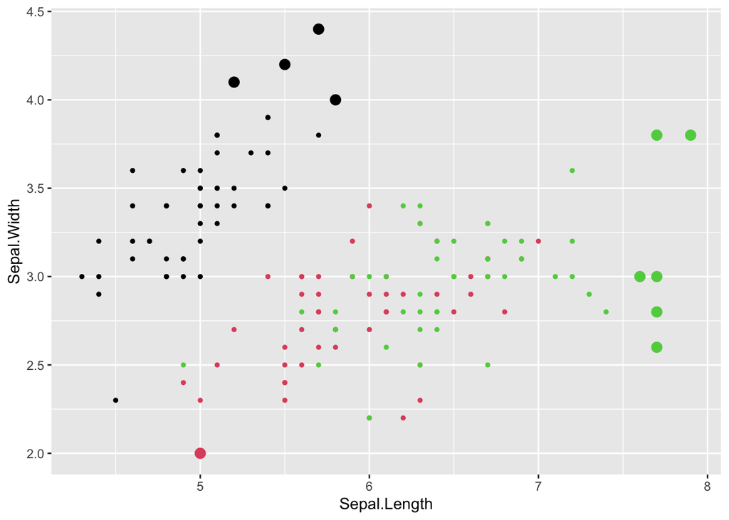

```r
# the flowers whose measured widths and lengths are exceptionally large or small
flower.outliers <- (apply(t((t(iris[,1:4]) < params$min) + (t(iris[,1:4]) > params$max)),1,sum)>0)
ggplot(iris, aes(x=Sepal.Length, y=Sepal.Width)) +
      geom_point(colour=as.numeric(iris$Species), size= flower.outliers*2 + 1)
```

# Exercice 4 : Equiprobability Ellipses

Let $(x^{1}, \ldots, x^{p})$ are i.i.d. variables following $\mathcal{N}(0,1)$ , then $\left(x^{1}, \ldots, x^{p}\right) \sim \mathcal{N}_{p}\left(0, I_{p}\right)$.

Find a matrix $A$ of size $(p, p)$ such that $A x$ has variance $\Sigma$, i.e. $A A^{t}=\Sigma$.

Then we obtain:
$$\boldsymbol{y} = A\boldsymbol{x} + \boldsymbol{\mu} \sim \mathcal{N}_{p}\left(0, \Sigma \right)$$

If $\boldsymbol{x} \sim \mathcal{N}_{p}(\boldsymbol{\mu}, \Sigma)$ so that $\boldsymbol{y}=\Sigma^{-1 / 2}(\boldsymbol{x}-\mu) \sim \mathcal{N}_{p}\left(0, I_{p}\right)$ and we obtain:
$$Q=\boldsymbol{y}^{t} \boldsymbol{y} \sim \chi_{p}^{2}$$
The equation below show the probability of $Q$:
$$P(Q \leq q)=\alpha$$
with $q=\chi_{p, \alpha}^{2}$ defines an $\alpha - level$ of equiprobability ellipsoid.

- Generate 1000 observations of a two-dimensional normal distribution $\mathcal{N}_{p}\left(\mu, \Sigma \right)$ with:

$$\mu=\begin{pmatrix}
0 \\ 0
\end{pmatrix}$$

$$\Sigma=\begin{pmatrix}
2 & 1 \\ 1 & 0.75
\end{pmatrix}$$

```r
# par(mfrow=c(1,3)) # pour partager l'affichage en 2
sigma <- matrix(c(2,1,1,0.75),2,2) # la matrice de grand sigma (matrice de variance)
A <- chol(sigma)
# check the sigma matrix
t(A)%*%A
```

```
##      [,1] [,2]
## [1,]    2 1.00
## [2,]    1 0.75
```

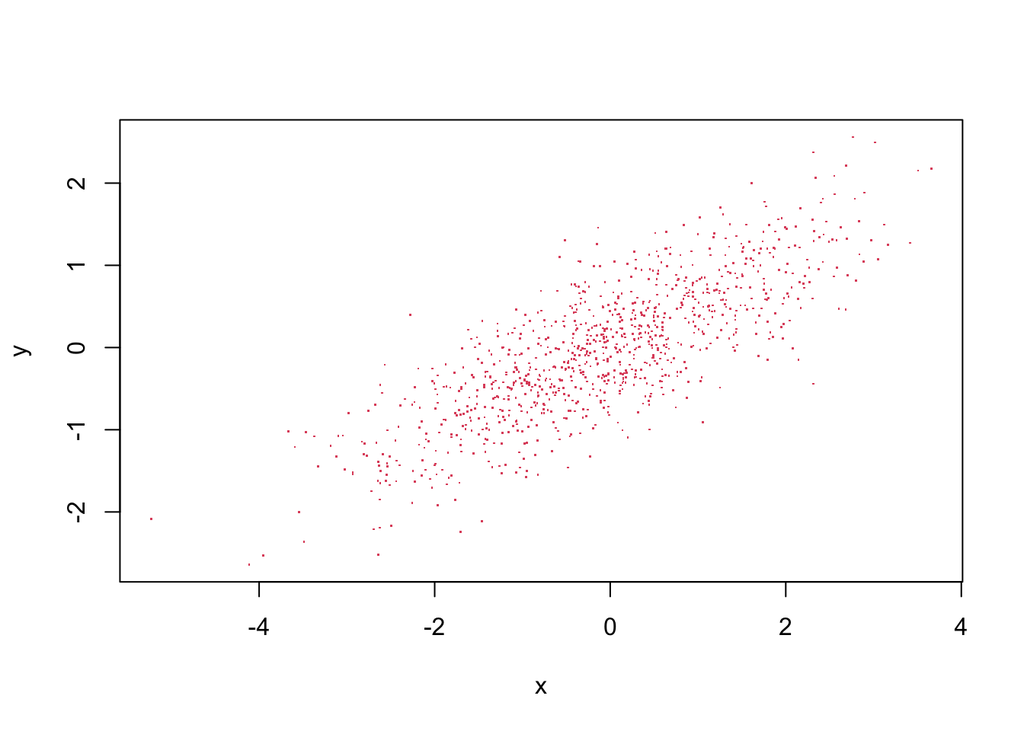

```r
Y <- matrix(rnorm(2000),1000,2) %*% A # une matrice avec 1000 lignes et 2 colonnes
# le grapghe de Y
plot(Y, xlab = "x", ylab = "y", pch = ".", col="2")
```

### Draw the ellipses of equiprobability of the multiples of 5%

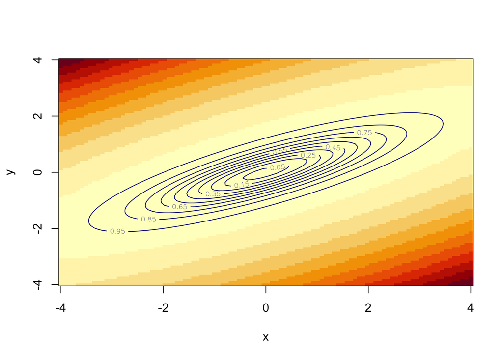

```r
x <- seq(-4,4,length = 100)
y <- seq(-4,4,length = 100)
sigmainv <- solve(sigma) # inverse matrix of sigma
a <- sigmainv[1,1] # THE ELEMENT OF 1ST ROW AND 1ST COLUMN
b <- sigmainv[2,2]
c <- sigmainv[1,2]
z <- outer(x,y,function(x,y) (a*x^2 + b*y^2 + 2*c*x*y)) # the function of an ellipse
image(x,y,z)
p <- seq(0.05,0.95,by=0.1)
Q <- qchisq(p, df=2)
contour(x,y,z,col = "blue4", levels = Q, labels = p, add=T)
```

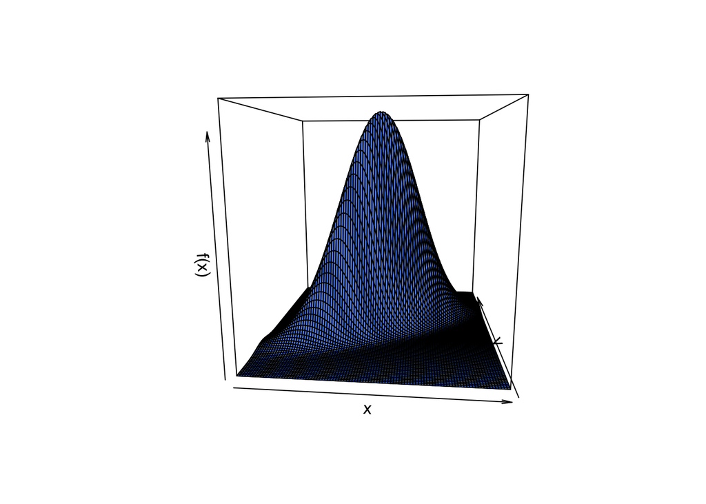

```r
persp(x,y,1/(2*pi)*det(sigmainv)^(-1/2)*exp(-0.5*z), col = "cornflowerblue", theta = 5, phi = 10, zlab = "f(x)")
```